# Data Analytics; Assignment V

04/10/2021

# Week 6: Integer Linear Programming

## **Part I (Team C)**

#### The flow shop scheduling problem

This task considers a typical scheduling problem, where several tasks have to be performed by several machines/employees (in this case two).

Two mechanics, Tom and John, work at an auto repair shop and are planning the repairs for the coming day. They have agreed to finish the repair and maintenance of six cars. On any car, Tom will always first do the repairs, then John will do the maintenance (changing the oil, checking the brakes, etc.). They estimate the time needed for each car as follows (all values in minutes).

| Car | \| | Time for repairs | \| | Time for maintenance |
| --- | --- | --- | --- | --- |
| A | \| | 90 | \| | 75 |
| B | \| | 120 | \| | 45 |
| C | \| | 105 | \| | 80 |
| D | \| | 60 | \| | 75 |
| E | \| | 30 | \| | 60 |
| F | \| | 60 | \| | 80 |

Tom and John would like to work on the cars in an order that lets them finish all tasks as early as possible.

$\textbf{1.}$ There is a simple rule that can be applied to find the optimal solution for this problem. Apply [Johnson’s rule](https://en.wikipedia.org/wiki/Johnson%27s_rule) to the data above and determine when Tom and John are finished. (Search for additional examples if you do not know how to apply Johnson’s rule).

- Johnson’s rule:
- List the jobs and their times at each work center.
- Select the job with the shortest activity time. If that activity time is for the first work center, then schedule the job first. If that activity time is for the second work center then schedule the job last. Break ties arbitrarily.
- Eliminate the shortest job from further consideration.
- Repeat steps 2 and 3, working towards the center of the job schedule until all jobs have been scheduled.

Apply to Johnshon’s rule, we can get the best job sequence : E > D > F > C > A > B  
Calculating manully, The total process time is 510 mins.

$\textbf{2.}$ Develop an integer linear programming formulation for the above problem for any number of jobs and any set of processing times. Implement the linear programme in R and find the optimal solution to the instance above. Additionally, you can test the linear programme by using randomly generated larger instances as it is done in Example 4 (Minimizing the weighted sum of completion times).

${Parameters:}$

$p_j^A$: processing time of job $j$ on machine $A$

$p_j^B$: processing time of job $j$ on machine $B$

$M$: a large number greater than the sum of all processing times

${Variables:}$

$s_j^A$: start time of job $j$ on machine $A$

$s_j^B$: start time of job $j$ on machine $B$

$C$: completion time of last job on machine $B$

$y_{ij}$: binary variable that equals 1 if job $i$ is processed before job $j$, and 0 if job $j$ is processed before job $i$

${Hint:}$ Use constraints similar to those in Example 4.

Add constraints

- either job i starts before j or vice versa
- this constraint is omitted for i==j, as otherwise the ILP becomes infeasible
- Only when A completed, B can start
- the total completion time need to be at least equal or more than the starting time of machine B’s last job.
- only one job be processed in machine A
- only one job be processed in machine B

```r
# load these packages (intall when used for the first time)
library(ompr)
library(magrittr)
library(ompr.roi)
library(ROI.plugin.glpk)

Auto_time <- matrix(c(90,75,
                      120, 45,
                      105,80,
                      60,75,
                      30,60,
                      60,80),nrow=6,ncol=2, byrow = TRUE)


# n: number of jobs
n <- 6
# P: maximum processing time of a job
#P <- 5
# W: maximum weight of a job
#W <- 5

# set the process time for machine A & B
pjA <- Auto_time[,1]
pjB <- Auto_time[,2]

# M: a large value, can be set to equal the sum of processing times
M <- sum(pjA+pjB)

# here we create a list of n randomly generated we
# next the ILP model is created, compare this to the ILP model presented in the lecture
model <- MIPModel() %>%
  # 1 iff job i starts before job j, 0 otherwise
  add_variable(y[i, j], i = 1:n, j = 1:n, type = "binary") %>%

  # start time of machine A&B
  add_variable(sA[i], i = 1:n, type = "continuous", lb=0) %>%
  add_variable(sB[i], i = 1:n, type = "continuous", lb=0) %>%

  # Create valuable for completion
  add_variable(C, type = "continuous", lb=0) %>%

  #minimize the sum of completion times
  set_objective(C, "min") %>%

  #Add constraints

  # either job i starts before j or vice versa
  # this constraint is omitted for i==j, as otherwise the ILP becomes infeasible
  add_constraint(y[i,j] + y[j,i] == 1, i = 1:n, j = 1:n, i!=j) %>%

  #Only when A completed, B can start
  add_constraint(sB[i] >= sA[i] + pjA[i], i = 1:n) %>%

  # the total completion time need to be at least equal or more than the starting time of machine B's last job.
  add_constraint(C >= sB[i]+pjB[i], i = 1:n) %>%

  #only one job be processed in machine A
  add_constraint(M*y[i,j]+sA[i] >= sA[j]+pjA[j], i = 1:n, j= 1:n) %>%

   #only one job be processed in machine B
  add_constraint(M*y[i,j]+sB[i] >= sB[j]+pjB[j], i = 1:n, j= 1:n)

model
```

```
## Mixed integer linear optimization problem
## Variables:
##   Continuous: 13
##   Integer: 0
##   Binary: 36
## Model sense: minimize
## Constraints: 114
```

```r
# the model is solved using the glpk plugin
result <- solve_model(model, with_ROI(solver = "glpk", verbose = TRUE))
```

```
## <SOLVER MSG>  ----
## GLPK Simplex Optimizer, v4.65
## 114 rows, 49 columns, 276 non-zeros
##       0: obj =   0.000000000e+00 inf =   6.190e+03 (114)
##     105: obj =   1.850000000e+02 inf =   1.402e-15 (0)
## OPTIMAL LP SOLUTION FOUND
## GLPK Integer Optimizer, v4.65
## 114 rows, 49 columns, 276 non-zeros
## 36 integer variables, all of which are binary
## Integer optimization begins...
## Long-step dual simplex will be used
## +   105: mip =     not found yet >=              -inf        (1; 0)
## +   207: >>>>>   5.450000000e+02 >=   2.700000000e+02  50.5% (11; 2)
## +   239: >>>>>   5.350000000e+02 >=   2.700000000e+02  49.5% (16; 3)
## +   260: >>>>>   5.100000000e+02 >=   3.000000000e+02  41.2% (16; 8)
## +  1138: mip =   5.100000000e+02 >=     tree is empty   0.0% (0; 477)
## INTEGER OPTIMAL SOLUTION FOUND
## <!SOLVER MSG> ----
```

```r
# display the results for the start time variables
result$solution
```

```
## y[1,1] y[1,2] y[1,3] y[1,4] y[1,5] y[1,6] y[2,1] y[2,2] y[2,3] y[2,4] y[2,5]
##      1      1      1      1      1      1      0      1      0      0      0
## y[2,6] y[3,1] y[3,2] y[3,3] y[3,4] y[3,5] y[3,6] y[4,1] y[4,2] y[4,3] y[4,4]
##      0      0      1      1      1      0      1      0      1      0      1
## y[4,5] y[4,6] y[5,1] y[5,2] y[5,3] y[5,4] y[5,5] y[5,6] y[6,1] y[6,2] y[6,3]
##      0      1      0      1      1      1      1      1      0      1      0
## y[6,4] y[6,5] y[6,6]  sA[1]  sA[2]  sA[3]  sA[4]  sA[5]  sA[6]  sB[1]  sB[2]
##      0      0      1      0    345    120    225     90    285     90    465
##  sB[3]  sB[4]  sB[5]  sB[6]      C
##    225    305    165    380    510
```

```r
result$objective_value
```

```
## [1] 510
```

Based on the model, the best solution:  
Car A > Car E > Car C > Car D > Car F > Car B

The total processing time is 510 mins

$\textbf{3.}$ Discuss the advantages and disadvantages of using either a rule like Johnson’s rule or applying linear programming to this problem.

- The optimized time calculated by Johnson’s rule and Integer linear programming model are both 510mins.
- We think that the advantages for the Integer linear programming model is it’s scabilitoty.  
  Any variables and constraints that can translate to logic can be adopt to Integer linear programming model; On the other hand, Johnson’s rule got more limitations on the number of machines and the work sequences.

## **Part II (Team D)**

#### The capacitated warehouse location problem

In this task you will consider an extension to the warehouse location problem that was introduced in the lecture (Example 3). In that example there is a set of customers which have to be assigned to potential warehouse locations. In the capacitated warehouse location problem the following additional data is given:

$d_i$: the demand of customer $i$

$c_j$: the capacity of warehouse location $j$

$\textbf{1.}$ Modify the integer programming formulation given for Example 3 such that in any feasible solution, the total demand of customers assigned to a warehouse does not exceed its capacity. Note that it is allowed that demand of a customer can be split to two or more different warehouses.

$\textbf{2.}$ Modify the given R implementation so that it implements your new integer linear programme.

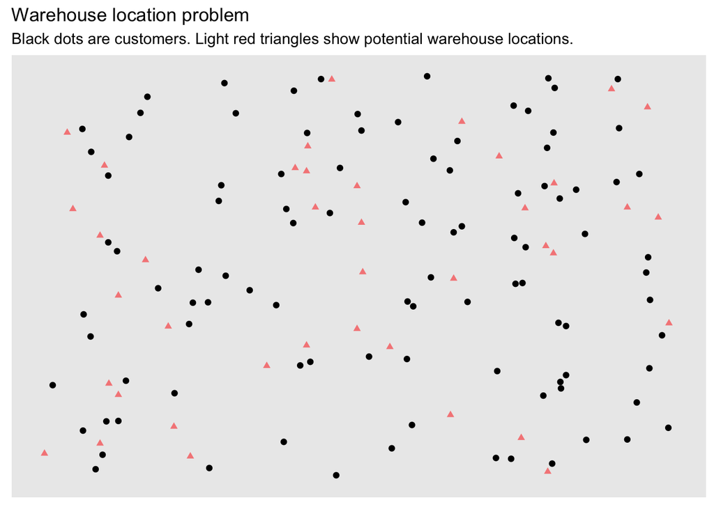

```r
# load these packages
library(ompr)
library(ggplot2)
library(magrittr)
library(ompr.roi)
library(ROI.plugin.glpk)
# whose dimensions are determined by the grid size
grid_size <- 1000

# n: number of customers
n <- 100

# Create a list of n randomly generated customer locations
customer_locations <- data.frame(
  id = 1:n,
  x = round(runif(n) * grid_size),
  y = round(runif(n) * grid_size)
)

# m: number of potential locations
m <- 40

# Create a list of m randomly generated warehouse locations
warehouse_locations <- data.frame(
  id = 1:m,
  x = round(runif(m) * grid_size),
  y = round(runif(m) * grid_size)
)

# We generate a list of random fixed costs for the m warehouses
fixedcost <- round(rnorm(m, mean = grid_size * 10, sd = grid_size * 2))
transportcost <- function(i, j) {
  customer <- customer_locations[i, ]
  warehouse <- warehouse_locations[j, ]
  round(sqrt((customer$x - warehouse$x)^2 + (customer$y - warehouse$y)^2))
}

# here we plot the locations on the grid
p <- ggplot(customer_locations, aes(x, y)) +
  geom_point() +
  geom_point(data = warehouse_locations, color = "red", alpha = 0.5, shape = 17) +
  scale_x_continuous(limits = c(0, grid_size)) +
  scale_y_continuous(limits = c(0, grid_size)) +
  theme(axis.title = element_blank(),
        axis.ticks = element_blank(),
        axis.text = element_blank(), panel.grid = element_blank())
p + ggtitle("Warehouse location problem",
            "Black dots are customers. Light red triangles show potential warehouse locations.")
```

```r
model <- MIPModel() %>%

# 1 iff i gets assigned to warehouse j
add_variable(x[i, j], i = 1:n, j = 1:m, type = "binary") %>%

# 1 iff warehouse j is built
add_variable(y[j], j = 1:m, type = "binary")  %>%

# minimize the total cost
set_objective(sum_expr(transportcost(i, j) * x[i, j], i = 1:n, j = 1:m) +
              sum_expr(fixedcost[j] * y[j], j = 1:m), "min") %>%

#A customer can be a least split to one warehouse
add_constraint(sum_expr(x[i, j], j = 1:m) >= 2, i = 1:n) %>%

#A customer can be to more different warehouses
add_constraint(sum_expr(x[i, j], j = 1:m) <= m, i = 1:n) %>%

# if a customer is assigned to a warehouse, then this warehouse must be built
add_constraint(x[i,j] <= y[j], i = 1:n, j = 1:m)
model
```

```
## Mixed integer linear optimization problem
## Variables:
##   Continuous: 0
##   Integer: 0
##   Binary: 4040
## Model sense: minimize
## Constraints: 4200
```

```r
result <- solve_model(model, with_ROI(solver = "glpk", verbose = TRUE))
```

```
## <SOLVER MSG>  ----
## GLPK Simplex Optimizer, v4.65
## 4200 rows, 4040 columns, 16000 non-zeros
##       0: obj =   0.000000000e+00 inf =   2.000e+02 (100)
##     240: obj =   1.257460000e+05 inf =   0.000e+00 (0)
## Perturbing LP to avoid stalling [397]...
## Removing LP perturbation [2784]...
## *  2784: obj =   8.618100000e+04 inf =   0.000e+00 (0) 5
## OPTIMAL LP SOLUTION FOUND
## GLPK Integer Optimizer, v4.65
## 4200 rows, 4040 columns, 16000 non-zeros
## 4040 integer variables, all of which are binary
## Integer optimization begins...
## Long-step dual simplex will be used
## +  2784: mip =     not found yet >=              -inf        (1; 0)
## +  2784: >>>>>   8.618100000e+04 >=   8.618100000e+04   0.0% (1; 0)
## +  2784: mip =   8.618100000e+04 >=     tree is empty   0.0% (0; 1)
## INTEGER OPTIMAL SOLUTION FOUND
## <!SOLVER MSG> ----
```

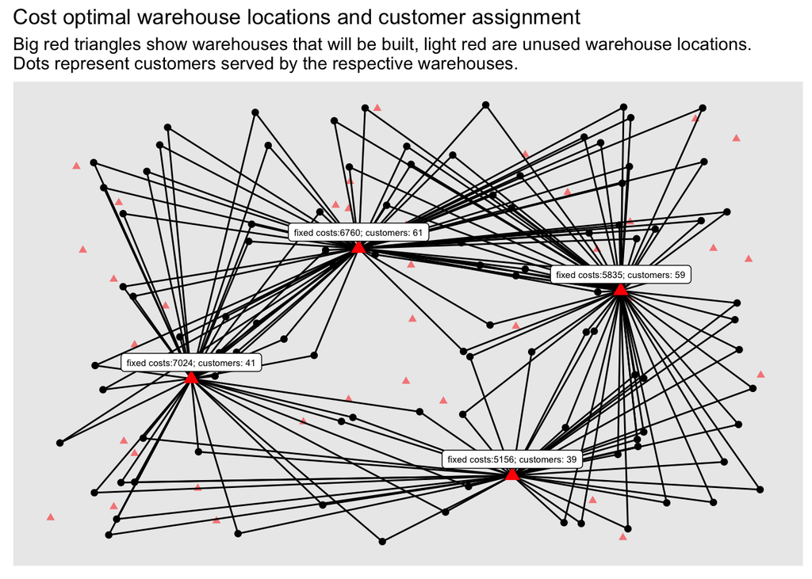

```r
# from the solution we create a list that contains the matches of customers to warehouses
suppressPackageStartupMessages(library(dplyr))
matching <- result %>%
get_solution(x[i,j]) %>%
filter(value > .9) %>%
select(i, j)

plot_assignment <- matching %>%
  inner_join(customer_locations, by = c("i" = "id")) %>%
  inner_join(warehouse_locations, by = c("j" = "id"))

customer_count <- matching %>% group_by(j) %>% summarise(n = n()) %>% rename(id = j)

plot_warehouses <- warehouse_locations %>%
  mutate(costs = fixedcost) %>%
  inner_join(customer_count, by = "id") %>%
  filter(id %in% unique(matching$j))
p +
  geom_segment(data = plot_assignment, aes(x = x.y, y = y.y, xend = x.x, yend = y.x)) +
  geom_point(data  = plot_warehouses, color = "red", size = 3, shape = 17) +
  ggrepel::geom_label_repel(data  = plot_warehouses,
                            aes(label = paste0("fixed costs:", costs, "; customers: ", n)),
                            size = 2, nudge_y = 20) +
  ggtitle(paste0("Cost optimal warehouse locations and customer assignment"),
          "Big red triangles show warehouses that will be built, light red are unused warehouse locations.
Dots represent customers served by the respective warehouses.")
```

$\textbf{3.}$ Test the implementation with various parameters. That means you should also adapt the generation of the input values such as demand and capacities.